## ECON664: Codes for Export and Policy Suggestion for the Netherlands

#### Author: Eric Hsienchen Chu

#### Last revised: December 20, 2023

### Data Importation

```r
## Warning: check working directory FIRST
pwt = read.dta13("../Econ664_Final_Assignment/data/final-pwt.dta")
industry_flow = read.dta13("../Econ664_Final_Assignment/data/final-industryflows.dta")
gravity = read.dta13("../Econ664_Final_Assignment/data/final-gravity.dta")
```

#### Data Structures

For **pwt** data:

- `countrycode`: 3-letter ISO country code
- `rgdpo`: Output-side real GDP at chained PPPs (in mil. 2017US$)
- `pop`: population (in mil)
- `hc`: human capital index
- `cn`: Capital stock at current PPPs (in mil. 2017US$)

For **industry_flow** data:

- `value`: iso’s exports, $ million
- `value_wd`: global exports, $ million

For **gravity** data:

- variable definitions follow the [PSET2](https://github.com/hsienc/Issues-in-International-Trade/blob/f021dbe80f3bd911e7f0aba721a97488a3a78642/ECON664_ps2.pdf)

#### SECTION 1: RECENT ECONOMIC PERFORMANCE OF THE NETHERLANDS

To summarize the Netherlands (NLD) econ growth, I use `pwt` data to showcase the output-side real GDP (in mils 2017US$). The summary of the Dutch’s economy is twofold. I first compare the Netherlands against all EU & Central Asia, which yields an aggregate level of regional economy overview. The second comparison goes by putting the Netherlands against the EU members, which highlights the within-group comparison.

(Note: The EU member list is retrieved at [The Country Profiles](https://european-union.europa.eu/principles-countries-history/country-profiles_en), with 27 countries listed by December 11, 2023.)

```r
EU_members = c("AUT", "BEL", "BGR", "HRV", "CYP", "CZE", "DNK", "EST", "FIN", "FRA", "DEU", "GRC", "HUN","IRL", "ITA", "LVA", "LTU", "LUX", "MLT", "NLD", "POL", "PRT", "ROU", "SVK", "SVN", "ESP", "SWE")
#NLD_neighbors = c("BEL", "DEU")
yr_period = seq(1980, 2019, by = 1)

# Check: country codes specifications
stopifnot(length(EU_members) == 27)
stopifnot(all(EU_members %in% pwt$countrycode))
#stopifnot(all(NLD_neighbors %in% pwt$countrycode))
```

```r
fig1a_tab = pwt %>%
  select(countrycode, year, rgdpo, region) %>%
  filter(year %in% yr_period, region == "Europe & Central Asia") %>%
  group_by(year) %>%
  mutate(group_rgdpo_25th = quantile(rgdpo, 0.25, na.rm = T),
         group_rgdpo_median = quantile(rgdpo, 0.5, na.rm = T),
         group_rgdpo_75th = quantile(rgdpo, 0.75, na.rm = T)) %>%
  ungroup() %>%
  summarise(year = year,
            country = countrycode,
            rgdpo = rgdpo,
            group_rgdpo_25th = group_rgdpo_25th,
            group_rgdpo_median = group_rgdpo_median,
            group_rgdpo_75th = group_rgdpo_75th
            )

fig1a_tab
```

```
## # A tibble: 1,920 × 6
##     year country  rgdpo group_rgdpo_25th group_rgdpo_median group_rgdpo_75th
##    <int> <chr>    <dbl>            <dbl>              <dbl>            <dbl>
##  1  1980 ALB      9965.          101927.            152806.          369811.
##  2  1981 ALB     10363.          103647.            152378.          359787.
##  3  1982 ALB     10392.          104751.            153065.          349888.
##  4  1983 ALB     10742.          106291.            156259.          350789.
##  5  1984 ALB     10857.          105909.            155367.          357580.
##  6  1985 ALB     10957.          107578.            158705.          349436
##  7  1986 ALB     11511.          117056.            166262.          365317.
##  8  1987 ALB     11730.          122715.            173161.          369195.
##  9  1988 ALB     11491.          120676.            184286.          383594.
## 10  1989 ALB     12432.          125636.            188329.          400006.
## # … with 1,910 more rows
```

#### Figure 1a. The Dutch’s Output-side real GDP against Europe & Central Asia (25-75th)

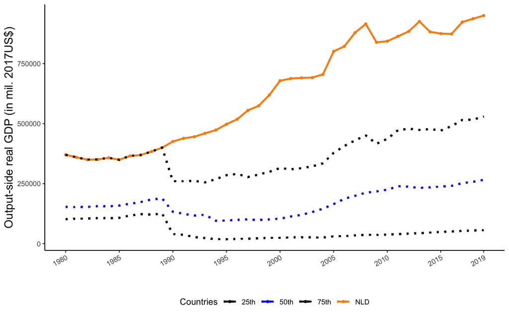

```r
fig1b_tab = pwt %>%
  select(countrycode, year, rgdpo, region) %>%
  filter(year %in% yr_period, countrycode %in% EU_members) %>%
  group_by(year) %>%
  mutate(group_rgdpo_25th = quantile(rgdpo, 0.25, na.rm = T),
         group_rgdpo_median = quantile(rgdpo, 0.5, na.rm = T),
         group_rgdpo_75th = quantile(rgdpo, 0.75, na.rm = T)) %>%
  ungroup() %>%
  summarise(year = year,
            country = countrycode,
            rgdpo = rgdpo,
            group_rgdpo_25th = group_rgdpo_25th,
            group_rgdpo_median = group_rgdpo_median,
            group_rgdpo_75th = group_rgdpo_75th
            )

fig1b_tab
```

```
## # A tibble: 1,080 × 6
##     year country   rgdpo group_rgdpo_25th group_rgdpo_median group_rgdpo_75th
##    <int> <chr>     <dbl>            <dbl>              <dbl>            <dbl>
##  1  1980 AUT     152806.           95120.            152364.          277251.
##  2  1981 AUT     152378.           97793.            152284.          264548.
##  3  1982 AUT     153065.           99434.            150213.          260262.
##  4  1983 AUT     156259.          101915.            150876.          275742.
##  5  1984 AUT     155367.          102089.            152162.          295401.
##  6  1985 AUT     158705.          104540.            156624.          309522.
##  7  1986 AUT     166262.          112028.            163622.          328459.
##  8  1987 AUT     173161.          118351.            166403.          341464.
##  9  1988 AUT     184286.          126248.            177746.          361554.
## 10  1989 AUT     194189.          129426.            183948.          378114.
## # … with 1,070 more rows
```

#### Figure 1b. The Dutch’s Output-side real GDP against EU members

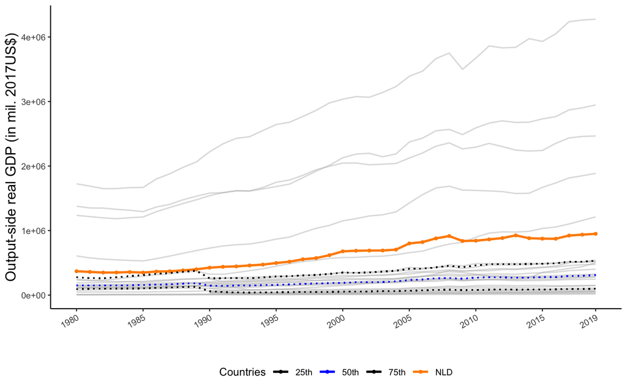

#### SECTION 2: EXPLORATION OF THE NETHERLANDS EXPORT PATTERNS

```r
NLD_industry_flow = industry_flow %>%
  filter(iso_o == "NLD", year <= 2021) # 2022 has missing values over almost all countries


head(NLD_industry_flow)
```

```
##   year iso_o hs2    value value_wd
## 1 1995   NLD  01 530.6730 9531.228
## 2 1996   NLD  01 464.0726 9368.053
## 3 1997   NLD  01 421.9798 8480.828
## 4 1998   NLD  01 343.5051 8660.057
## 5 1999   NLD  01 383.3049 8665.994
## 6 2000   NLD  01 347.5298 9034.108
```

```r
# calculate growth rate recursively
period = seq(min(NLD_industry_flow$year), max(NLD_industry_flow$year), by = 1)

temp = pwt %>%
  filter(year %in% period, countrycode == "NLD") %>%
  select(year, rgdpo) %>%
  group_by(year)
```

```r
# overall export growth
fig2_NLD_export_growth = NLD_industry_flow %>%
  group_by(year) %>%
  summarise(total_export = sum(value)) %>%
  mutate(diff_growth = total_export - lag(total_export), # Difference in total_export between years
         growth_rate = ( diff_growth / (year - lag(year)) )/lag(total_export)*100,
         log_diff_rate = (log(total_export) - log(lag(total_export)))*100 )

fig2_NLD_export_growth = fig2_NLD_export_growth %>%
  left_join(temp, by = "year") %>%
  mutate(export_share_rgdp = total_export/rgdpo*100)

fig2_NLD_export_growth
```

[output not shown]

#### Figure 2. Export Profile: 1995-2021

[figure not shown]

The `Revealed Comparative Advantage (RCA)` index is calculated as:

$$RCA^i_k = \frac{X^i_k/X^i}{X_k/X} = \frac{X^i_k/\sum_k X^i_k}{\sum_i
X^i_k / \sum_i\sum_k X^i_k}$$
where $X^i_k$ is country $i$’s exports in industry $k$, $X^i$ is country $i$’s total exports, $X_k$ is world exports of sector $k$, and $X$ is total world exports.

```r
#RCA comparison: what are the most "competitive" industry for the Dutch's export

RCA_2015 = NLD_industry_flow %>%
  filter(year == 2015) %>%
  mutate(RCA_2015 = (value / sum(value))/(value_wd/sum(value_wd)) ) %>%
  select(iso_o, hs2, RCA_2015)

RCA_2016 = NLD_industry_flow %>%
  filter(year == 2016) %>%
  mutate(RCA_2016 = (value / sum(value))/(value_wd/sum(value_wd)) ) %>%
  select(iso_o, hs2, RCA_2016)


RCA_2017 = NLD_industry_flow %>%
  filter(year == 2017) %>%
  mutate(RCA_2017 = (value / sum(value))/(value_wd/sum(value_wd)) ) %>%
  select(iso_o, hs2, RCA_2017)

RCA_2018 = NLD_industry_flow %>%
  filter(year == 2018) %>%
  mutate(RCA_2018 = (value / sum(value))/(value_wd/sum(value_wd)) ) %>%
  select(iso_o, hs2, RCA_2018)

RCA_2019 = NLD_industry_flow %>%
  filter(year == 2019) %>%
  mutate(RCA_2019 = (value / sum(value))/(value_wd/sum(value_wd)) ) %>%
  select(iso_o, hs2, RCA_2019)

RCA_comparison = RCA_2015 %>%
  inner_join(RCA_2016, by = c("iso_o", "hs2")) %>%
  inner_join(RCA_2017, by = c("iso_o", "hs2")) %>%
  inner_join(RCA_2018, by = c("iso_o", "hs2")) %>%
  inner_join(RCA_2019, by = c("iso_o", "hs2")) %>%
  mutate(Five_yr_avg_RCA = round( ((RCA_2015 + RCA_2016 + RCA_2017 + RCA_2018 + RCA_2019)/5), 2)) %>%
  arrange(-Five_yr_avg_RCA)

RCA_comparison %>%
  select(-iso_o) %>%
  slice_max(Five_yr_avg_RCA, n=10, with_ties = T)
```

```
##    hs2 RCA_2015 RCA_2016 RCA_2017 RCA_2018 RCA_2019 Five_yr_avg_RCA
## 1   06 4.760332 4.668771 4.512178 4.443750 4.314531            4.54
## 2   18 3.565693 3.699856 3.634094 3.586393 3.384461            3.57
## 3   01 2.264589 2.439414 2.406652 2.176727 2.217244            2.30
## 4   14 2.233876 1.867471 2.387094 2.501492 2.180261            2.23
## 5   15 2.011910 2.101879 2.244224 2.201255 2.137025            2.14
## 6   20 2.086413 2.048783 1.953714 1.943833 1.847404            1.98
## 7   04 1.983662 1.950297 1.980704 2.033671 1.912040            1.97
## 8   08 1.864044 1.937116 1.978883 2.008194 1.998282            1.96
## 9   05 2.132092 1.971945 1.925029 1.926723 1.809198            1.95
## 10  99 2.306842 1.766605 1.655856 1.920236 1.524073            1.83
```

```r
# extra exercises
# compund annunal growth rate
NLD_industry_flow %>%
  filter(year == 2019 | year == 2015) %>%
  group_by(hs2) %>%
  summarise(year = year,
            value = value,
            CAGR_growth = round(((value[year == 2019]/value[year == 2015])^(1/(2019-2015+1)) - 1)*100, 2) )
```

```
## # A tibble: 194 × 4
## # Groups:   hs2 [97]
##    hs2    year value CAGR_growth
##    <chr> <int> <dbl>       <dbl>
##  1 01     2015 1211.        3.09
##  2 01     2019 1410.        3.09
##  3 02     2015 4148.        1.06
##  4 02     2019 4373.        1.06
##  5 03     2015 1957.        3.52
##  6 03     2019 2327.        3.52
##  7 04     2015 3827.        4.07
##  8 04     2019 4672.        4.07
##  9 05     2015  453.        2.23
## 10 05     2019  506.        2.23
## # … with 184 more rows
```

```r
# what are the top export industry (total value, not RCA)

top_export_2015 = NLD_industry_flow %>%
  filter(year == 2015) %>%
  rename(export_value_2015 = value) %>%
  select(iso_o, hs2, export_value_2015)

top_export_2016 = NLD_industry_flow %>%
  filter(year == 2016) %>%
  rename(export_value_2016 = value) %>%
  select(iso_o, hs2, export_value_2016)

top_export_2017 = NLD_industry_flow %>%
  filter(year == 2017) %>%
  rename(export_value_2017 = value) %>%
  select(iso_o, hs2, export_value_2017)

top_export_2018 = NLD_industry_flow %>%
  filter(year == 2018) %>%
  rename(export_value_2018 = value) %>%
  select(iso_o, hs2, export_value_2018)

top_export_2019 = NLD_industry_flow %>%
  filter(year == 2019) %>%
  rename(export_value_2019 = value) %>%
  select(iso_o, hs2, export_value_2019)

Top_export_comparison = top_export_2015 %>%
  inner_join(top_export_2016, by = c("iso_o", "hs2")) %>%
  inner_join(top_export_2017, by = c("iso_o", "hs2")) %>%
  inner_join(top_export_2018, by = c("iso_o", "hs2")) %>%
  inner_join(top_export_2019, by = c("iso_o", "hs2")) %>%
  mutate(Five_yr_avg_report = round( ((export_value_2015 + export_value_2016 + export_value_2017 + export_value_2018 + export_value_2019)/5), 2)) %>%
  arrange(-Five_yr_avg_report)

Top_export_comparison %>%
  select(-iso_o) %>%
  slice_max(Five_yr_avg_report, n=3, with_ties = T) %>%
  relocate(hs2, Five_yr_avg_report)
```

```
##   hs2 Five_yr_avg_report export_value_2015 export_value_2016 export_value_2017
## 1  27           62970.00          56883.06          49802.27          62128.27
## 2  85           56864.54          45976.05          47344.39          58437.55
## 3  84           55876.09          51686.70          51840.83          53762.73
##   export_value_2018 export_value_2019
## 1          75721.78          70314.60
## 2          65118.02          67446.71
## 3          61226.25          60863.96
```

#### SECTION 3: GRAVITY ANALYSIS ON BARRIERS IN BILATERAL TRADE

```r
# get NLD data

gravity_NLD = gravity %>%
  filter(iso_o == "NLD")

# take log for regression
gravity_NLD = gravity_NLD %>%
  mutate(lvalue = log(value),
         lgdp_od = log(gdp_o*gdp_d),
         ldistw = log(distw),
         lgdp_o  = log(gdp_o),
         lgdp_d  = log(gdp_d),
         # variables of interest
         lscaled_sci_2021 = log(scaled_sci_2021),
         lcomrelig = log(comrelig))
```

```r
# Baseline

reg_baseline = lm(lvalue ~ lgdp_o + lgdp_d + ldistw - 1,  data = gravity_NLD)
#texreg(reg_baseline, include.ci = FALSE)

tidy(reg_baseline) %>%
    mutate(sig = stars.pval(p.value))
```

```
## # A tibble: 3 × 6
##   term   estimate std.error statistic  p.value sig
##   <chr>     <dbl>     <dbl>     <dbl>    <dbl> <chr>
## 1 lgdp_o    0.230    0.0523      4.41 1.76e- 5 ***
## 2 lgdp_d    0.900    0.0335     26.9  3.60e-66 ***
## 3 ldistw   -1.01     0.0860    -11.8  2.54e-24 ***
```

```r
# cultural
reg_2 = lm(lvalue ~ lgdp_o + lgdp_d + ldistw + comlang_ethno + contig -1, data = gravity_NLD)
#texreg(reg_2, include.ci = FALSE)
tidy(reg_2) %>%
    mutate(sig = stars.pval(p.value))
```

```
## # A tibble: 5 × 6
##   term          estimate std.error statistic  p.value sig
##   <chr>            <dbl>     <dbl>     <dbl>    <dbl> <chr>
## 1 lgdp_o           0.208    0.0491      4.23 3.70e- 5 "***"
## 2 lgdp_d           0.910    0.0311     29.2  1.07e-70 "***"
## 3 ldistw          -0.983    0.0837    -11.7  4.73e-24 "***"
## 4 comlang_ethno    2.33     0.591       3.94 1.15e- 4 "***"
## 5 contig          -0.870    0.766      -1.14 2.57e- 1 " "
```

```r
# political
reg_3 = lm(lvalue ~ lgdp_o + lgdp_d + ldistw + comleg_posttrans + rta -1, data = gravity_NLD)
#texreg(reg_3, include.ci = FALSE)
tidy(reg_3) %>%
    mutate(sig = stars.pval(p.value))
```

```
## # A tibble: 5 × 6
##   term             estimate std.error statistic  p.value sig
##   <chr>               <dbl>     <dbl>     <dbl>    <dbl> <chr>
## 1 lgdp_o             0.213     0.0569     3.75  2.37e- 4 "***"
## 2 lgdp_d             0.901     0.0336    26.8   1.23e-65 "***"
## 3 ldistw            -0.982     0.0944   -10.4   3.02e-20 "***"
## 4 comleg_posttrans  -0.0190    0.148     -0.129 8.98e- 1 " "
## 5 rta                0.139     0.161      0.864 3.89e- 1 " "
```

```r
reg_4 = lm(lvalue ~ lgdp_o + lgdp_d + ldistw + comlang_ethno + contig + comleg_posttrans + rta -1, data = gravity_NLD)
#texreg(reg4, include.ci = FALSE)
tidy(reg_4) %>%
    mutate(sig = stars.pval(p.value))
```

```
## # A tibble: 7 × 6
##   term             estimate std.error statistic  p.value sig
##   <chr>               <dbl>     <dbl>     <dbl>    <dbl> <chr>
## 1 lgdp_o             0.193     0.0534     3.61  4.03e- 4 "***"
## 2 lgdp_d             0.912     0.0312    29.2   3.20e-70 "***"
## 3 ldistw            -0.951     0.0911   -10.4   3.04e-20 "***"
## 4 comlang_ethno      2.38      0.597      3.99  9.47e- 5 "***"
## 5 contig            -0.877     0.770     -1.14  2.56e- 1 " "
## 6 comleg_posttrans  -0.0973    0.137     -0.708 4.80e- 1 " "
## 7 rta                0.141     0.148      0.949 3.44e- 1 " "
```